# PLIER Utils proof-of-concept

**J. Taroni 2018**

In this notebook, I aim to demonstrate the validity of implementation for a subset of PLIER custom functions. Specifically, checking the operations for:

- Training a PLIER model on a new dataset `PLIERNewData()`
- Applying a previously computed PLIER to a new dataset to get the LV x sample matrix (B) `GetNewDataB()`
- Reconstruction of input gene expression data with a PLIER model `GetReconstructedExprs()` and the evaluation function `GetReconstructionCorrelation()`

Here, I use the **NARES dataset** for convenience due to its relatively small size (n = 77).

#### Load libraries and custom functions

```r
library(AnnotationDbi)
library(PLIER)
source(file.path("util", "plier_util.R"))
```

```r
# plots directory specifically for this notebook
dir.create(file.path("plots", "01"), recursive = TRUE,
           showWarnings = FALSE)
```

#### NARES expression data

```r
# Read in PCL
nares.data <- readr::read_tsv(file.path("data", "expression_data",
                                         "NARES_SCANfast_ComBat.pcl"),
                              progress = FALSE)
```

Building a PLIER model requires HGNC symbol annotation, as this is what is included in the prior information (e.g., pathways, genesets) that is included in the package.

```r
symbol.obj <- org.Hs.eg.db::org.Hs.egSYMBOL
```

```r
mapped.genes <- AnnotationDbi::mappedkeys(symbol.obj)
symbol.list <- as.list(symbol.obj[mapped.genes])
symbol.df <- as.data.frame(cbind(names(symbol.list), unlist(symbol.list)))
colnames(symbol.df) <- c("EntrezID", "GeneSymbol")
# get gene column name to match to facilitate use with dplyr
colnames(nares.data)[1] <- "EntrezID"
# matching types
symbol.df$EntrezID <- as.integer(as.character(symbol.df$EntrezID))
# inner join
annot.nares.data <- dplyr::inner_join(symbol.df, nares.data, by = "EntrezID")
# only leave the matrix with gene symbol as rownames
exprs.mat <- dplyr::select(annot.nares.data, -EntrezID)
rownames(exprs.mat) <- exprs.mat$GeneSymbol
exprs.mat <- as.matrix(dplyr::select(exprs.mat, -GeneSymbol))
```

#### Train PLIER model

`PLIERNewData` is a wrapper function for applying PLIER to a new dataset. Expression data is row-normalized for use with PLIER. We use the following genesets that come with PLIER: `bloodCellMarkersIRISDMAP`, `svmMarkers`, and `canonicalPathways`. See also the [PLIER vignette](https://github.com/wgmao/PLIER/blob/a2d4a2aa343f9ed4b9b945c04326bebd31533d4d/vignettes/vignette.pdf).

```r
nares.plier <- PLIERNewData(exprs.mat)
```

```
Removing 1 pathways with too few genesComputing SVD
Done
```

```
[1] 47.1281
[1] "L2 is set to 47.1281023042499"
[1] "L1 is set to 23.5640511521249"
```

[output not shown]

[output cut: 126 more lines]

[output not shown]

#### Apply PLIER model to “new” expression dataset

The `GetNewDataB` function will first row-normalize and reorder the “new” input gene expression data (`exprs.mat`), and then using a previously computed PLIER model (`plier.model`, specifically the gene loadings and the L2 constant), get the new data into the PLIER model LV space. Here, we supply the NARES data as the expression data and the PLIER model that has already been trained on the same gene expression matrix.

```r
new.b.mat <- GetNewDataB(exprs.mat = exprs.mat,
                         plier.model = nares.plier)
# NARES B matrix from PLIERNewData
nares.b.mat <- nares.plier$B
```

We want to ensure that the two B matrices are the same.

```r
all.equal(nares.b.mat, new.b.mat)
```

```
[1] TRUE
```

#### Reconstruction of gene expression data

We reconstruct gene expression data from the gene loadings and LVs.

```r
nares.recon <- GetReconstructedExprs(z.matrix = as.matrix(nares.plier$Z),
                                     b.matrix = as.matrix(nares.plier$B))
```

Let’s evaluate the reconstruction. We’ll need the row-normalized NARES expression data (input) for comparison.

```r
nares.rownorm <- PLIER::rowNorm(exprs.mat)
nares.rownorm <- nares.rownorm[rownames(nares.recon), ]
```

Spearman correlation between input, row-normalized expression data and the reconstructed data. If correlation between the input and the reconstructed data is high, that suggests that reconstruction is “successful.” Given the different constraints in PLIER, we would not expect to perfectly (`rho = 1`) reconstruct the input data. This particular evaluation will be *most useful* when we look at applying a trained PLIER model to a test dataset.

```r
recon.correlation <- GetReconstructionCorrelation(true.mat = nares.rownorm,
                                                  recon.mat = nares.recon)
```

Plot density

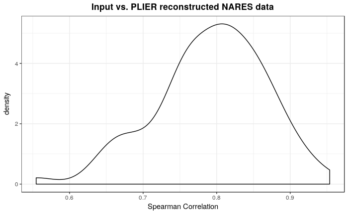

```r
# density plot
p <- ggplot2::ggplot(as.data.frame(recon.correlation),
                ggplot2::aes(x = recon.correlation)) +
      ggplot2::geom_density() +
      ggplot2::theme_bw() +
      ggplot2::labs(x = "Spearman Correlation",
                    title = "Input vs. PLIER reconstructed NARES data") +
      ggplot2::theme(plot.title = ggplot2::element_text(hjust = 0.5,
                                                        face = "bold"))
p
```

```r
png.file <- file.path("plots", "01",
                      "NARES_reconstructed_data_correlation_density.png")
ggplot2::ggsave(filename = png.file, plot = p, width = 7, height = 5,
                units = "in")
```